# 01 - Managing and operating objects in R

Francisco E. Fonturbel & Sebastian Cordero

22/December/2025

## Introduction to R

R is an open source platform that can be used to perform statistical analyses and many other things (genetics, maps, etc.). R is an **object-based programming language**, which means that it is based on creating, manipulating, and operating objects.

R objects are **case sensitive**. For example, “vector” and “Vector” are considered as different objects. Thus, if you are getting a recurrent error trying to call or operate an object, the first thing to do is check your spelling. Be sure that you are calling your object exactly as it was created (hint: the Environment tab on RStudio, located at the upper right corner, contains a list of all objects and functions currently loaded in R).

## Basic concepts

Before diving into data analysis, let’s understand some fundamental concepts that will make your R experience much smoother.

### What is a function?

A **function** is a command that receives information and returns a result. Think of it as a specialized machine that processes inputs and gives you outputs. The basic anatomy of a function is:

`function_name(argument1, argument2, ...)`

Here are some examples of basic functions:

```r
# mean() calculates the average of a set of numbers
mean(c(1, 2, 3, 4, 5))
```

```
## [1] 3
```

```r
# length() counts how many elements are in a vector
length(c("a", "b", "c"))
```

```
## [1] 3
```

```r
# sqrt() calculates the square root
sqrt(16)
```

```
## [1] 4
```

### Basic arithmetic operators

R can work as a powerful calculator. Here are the basic arithmetic operators:

```r
# Addition
2 + 3
```

```
## [1] 5
```

```r
# Subtraction
10 - 4
```

```
## [1] 6
```

```r
# Multiplication (use asterisk *)
5 * 6
```

```
## [1] 30
```

```r
# Division (use forward slash /)
20 / 4
```

```
## [1] 5
```

```r
# Exponentiation (use caret ^)
2^3
```

```
## [1] 8
```

### What is a variable?

A **variable** is a name that we assign to a value so we can reuse it later. The symbol `<-` assigns the value on the right to the name on the left:

```r
# Assigning values to variables
temperature <- 25.5
precipitation <- 120
num_species <- 15

# To access the value, simply type the variable name
temperature
```

```
## [1] 25.5
```

```r
precipitation
```

```
## [1] 120
```

```r
num_species
```

```
## [1] 15
```

```r
# We can use variables in calculations
temperature + 5
```

```
## [1] 30.5
```

### What is a vector?

A **vector** stores multiple values of the same type in an ordered sequence. The function `c()` (which stands for “concatenate” or “combine”) creates vectors:

```r
# Creating numeric vectors
week_temperatures <- c(22, 24, 26, 23, 25, 27, 24)
species_per_plot <- c(12, 15, 8, 20, 18, 10, 14)

# View the contents
week_temperatures
```

```
## [1] 22 24 26 23 25 27 24
```

```r
species_per_plot
```

```
## [1] 12 15  8 20 18 10 14
```

### Basic statistical functions for vectors

R has built-in functions to calculate statistics automatically:

```r
# Calculate the mean (average)
mean(week_temperatures)
```

```
## [1] 24.42857
```

```r
# Find the maximum value
max(species_per_plot)
```

```
## [1] 20
```

```r
# Find the minimum value
min(species_per_plot)
```

```
## [1] 8
```

```r
# Count how many elements are in the vector
length(species_per_plot)
```

```
## [1] 7
```

```r
# Calculate the standard deviation
sd(week_temperatures)
```

```
## [1] 1.718249
```

```r
# Calculate the sum
sum(species_per_plot)
```

```
## [1] 97
```

## Datasets

The primordial input in science is data. Regardless of our study field, we all use data (collected after hard fieldwork or long lab hours) and the quality of our analyses and papers depend on the quality of our data. Likewise, properly managing our data is crucial to have a smooth experience in R.

My first advice will be: please, **AVOID** the `openxlsx` library; it might seem to make your life easier but most of the time it will make your experience with R very hard.

Tips for loading your data without problem:

1. Prefer csv (comma-separated text) or txt (tab-separated text) formats to input your data in R.
2. Avoid spaces, periods, and commas in variable names.
3. Do not leave empty cells. If there is no data, use `NA` to fill those empty cells.

### Creating a data frame from scratch

A **data frame** is like a spreadsheet or table: it has rows and columns. We can create one by combining vectors:

```r
# First, create vectors for each column
tree_names <- c("Oak", "Pine", "Eucalyptus", "Carob", "Quillay")
height_m <- c(15.2, 22.8, 18.5, 12.1, 16.7)
diameter_cm <- c(45, 62, 38, 29, 41)
age_years <- c(25, 45, 30, 20, 35)

# Combine vectors into a data frame
tree_data <- data.frame(
  Species = tree_names,
  Height = height_m,
  Diameter = diameter_cm,
  Age = age_years
)

# View the data frame
print(tree_data)
```

```
##      Species Height Diameter Age
## 1        Oak   15.2       45  25
## 2       Pine   22.8       62  45
## 3 Eucalyptus   18.5       38  30
## 4      Carob   12.1       29  20
## 5    Quillay   16.7       41  35
```

### Exploring data frames

The `summary()` function provides a quick statistical overview of your data:

```r
summary(tree_data)
```

```
##    Species              Height         Diameter       Age
##  Length:5           Min.   :12.10   Min.   :29   Min.   :20
##  Class :character   1st Qu.:15.20   1st Qu.:38   1st Qu.:25
##  Mode  :character   Median :16.70   Median :41   Median :30
##                     Mean   :17.06   Mean   :43   Mean   :31
##                     3rd Qu.:18.50   3rd Qu.:45   3rd Qu.:35
##                     Max.   :22.80   Max.   :62   Max.   :45
```

To access a specific column, use the `$` operator:

```r
# Access the Height column
tree_data$Height
```

```
## [1] 15.2 22.8 18.5 12.1 16.7
```

```r
# Access the Species column
tree_data$Species
```

```
## [1] "Oak"        "Pine"       "Eucalyptus" "Carob"      "Quillay"
```

```r
# Calculate mean height
mean(tree_data$Height)
```

```
## [1] 17.06
```

### Adding new calculated columns

We can create new variables based on existing ones and add them to our data frame:

```r
# Estimate biomass using: Biomass = height × diameter² × 0.001
biomass_estimated <- tree_data$Height * (tree_data$Diameter^2) * 0.001

# Add the new column to our data frame
tree_data$Biomass <- biomass_estimated

# View the updated data frame
print(tree_data)
```

```
##      Species Height Diameter Age Biomass
## 1        Oak   15.2       45  25 30.7800
## 2       Pine   22.8       62  45 87.6432
## 3 Eucalyptus   18.5       38  30 26.7140
## 4      Carob   12.1       29  20 10.1761
## 5    Quillay   16.7       41  35 28.0727
```

### Example datasets

No data to test yet? Don’t worry! R has several example datasets to work with. Just type `data()` to see the available data in base R (some additional datasets may be available within other packages as well).

One of the nicest datasets is `iris`, which contains information on flower measurements of three species of the *Iris* genus.

```r
data(iris)
attach(iris)
names(iris)
```

```
## [1] "Sepal.Length" "Sepal.Width"  "Petal.Length" "Petal.Width"  "Species"
```

This dataset contains four columns with quantitative data and a fifth column with categorical values, corresponding to the different species.

Using the command `head()` we can examine the first 6 lines of the dataset and figure out how it looks:

```r
head(iris)
```

```
##   Sepal.Length Sepal.Width Petal.Length Petal.Width Species
## 1          5.1         3.5          1.4         0.2  setosa
## 2          4.9         3.0          1.4         0.2  setosa
## 3          4.7         3.2          1.3         0.2  setosa
## 4          4.6         3.1          1.5         0.2  setosa
## 5          5.0         3.6          1.4         0.2  setosa
## 6          5.4         3.9          1.7         0.4  setosa
```

And `tail()` shows us the last 6 rows:

```r
tail(iris)
```

```
##     Sepal.Length Sepal.Width Petal.Length Petal.Width   Species
## 145          6.7         3.3          5.7         2.5 virginica
## 146          6.7         3.0          5.2         2.3 virginica
## 147          6.3         2.5          5.0         1.9 virginica
## 148          6.5         3.0          5.2         2.0 virginica
## 149          6.2         3.4          5.4         2.3 virginica
## 150          5.9         3.0          5.1         1.8 virginica
```

How many species are present in this dataset? We may count them one by one or… just ask R:

```r
# Examining variable levels
levels(Species)
```

```
## [1] "setosa"     "versicolor" "virginica"
```

```r
# Creating an object to quantify how many levels we have
spp <- levels(Species)
length(spp)
```

```
## [1] 3
```

In this case there are only three species, but this is particularly useful for large datasets with many levels.

## First-aid plots: viewing our data

Before starting to analyze our data, it is always a good idea to make simple plots to describe them. Data visualization helps us understand patterns, identify outliers, and check assumptions before running statistical tests.

### Histograms

How are sepal length values distributed? Let’s make a histogram:

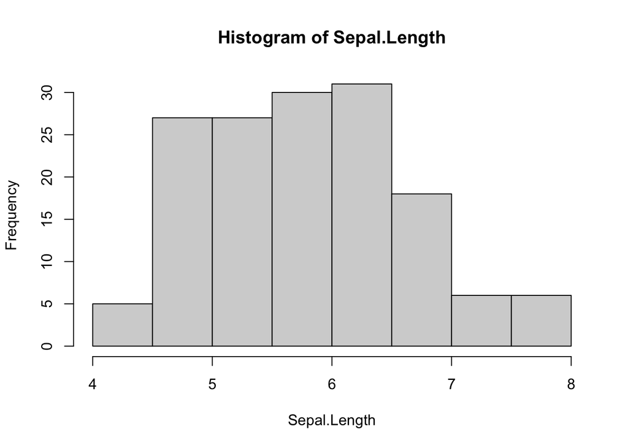

```r
hist(Sepal.Length)
```

Interesting! There is some variation on sepal length but the color is so dull… Why not give it some color?

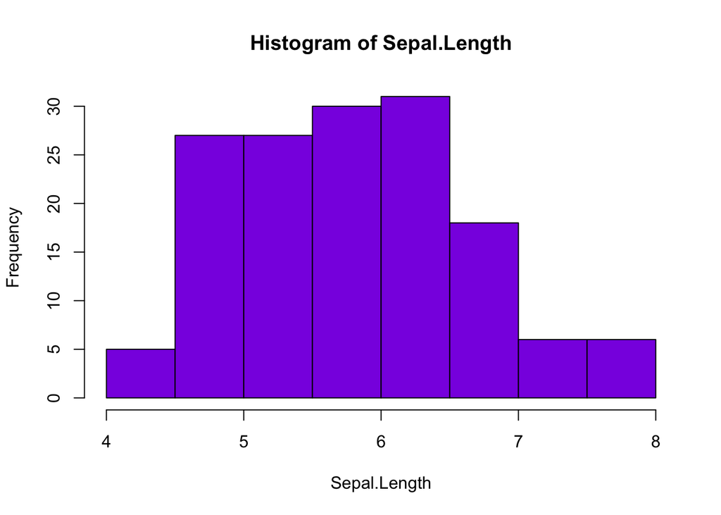

```r
hist(Sepal.Length, col = "blueviolet")
```

Much better! We can also add better labels:

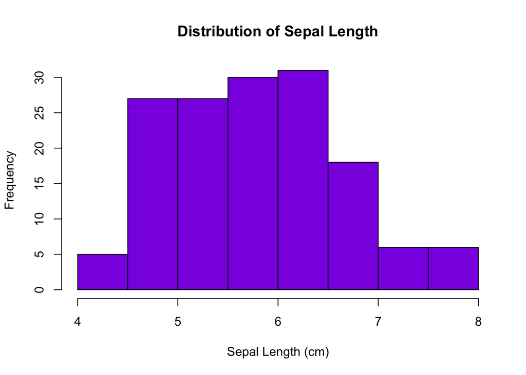

```r
hist(Sepal.Length,
     col = "blueviolet",
     main = "Distribution of Sepal Length",
     xlab = "Sepal Length (cm)",
     ylab = "Frequency")
```

### Barplots

Barplots are useful for displaying categorical comparisons. Let’s use our tree data:

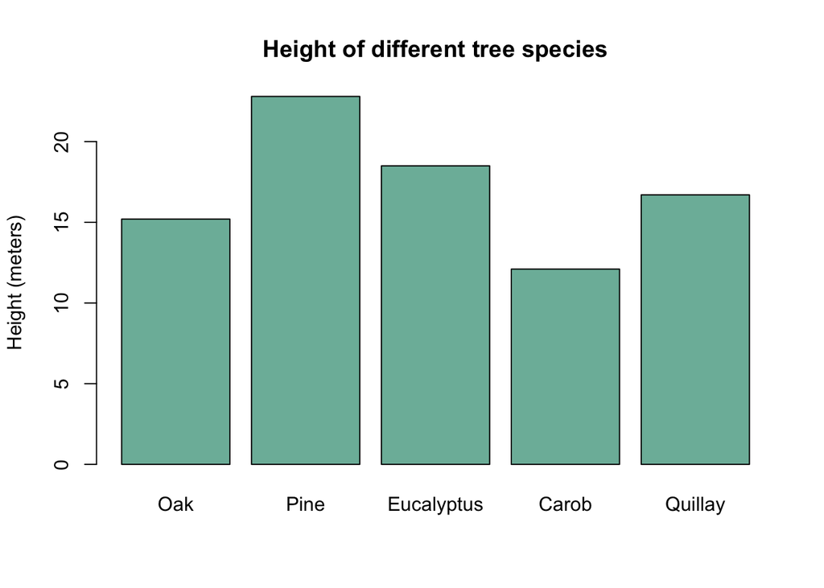

```r
barplot(tree_data$Height,
        names.arg = tree_data$Species,
        main = "Height of different tree species",
        ylab = "Height (meters)",
        col = "#7CB9A8")
```

### Scatterplots

How are sepal length and width related? Let’s make a scatterplot:

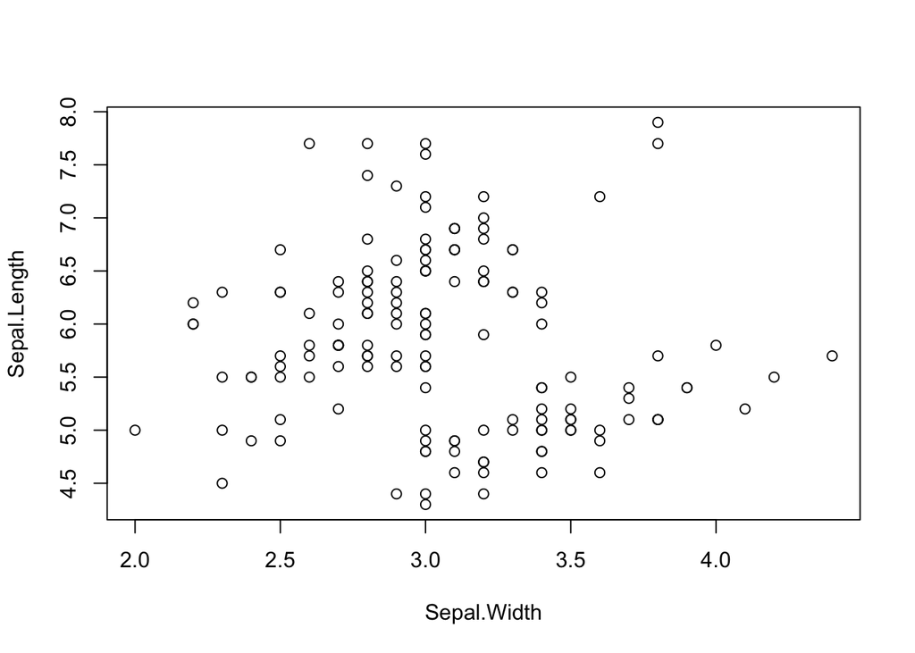

```r
plot(Sepal.Length ~ Sepal.Width)
```

We can add more information to the plot:

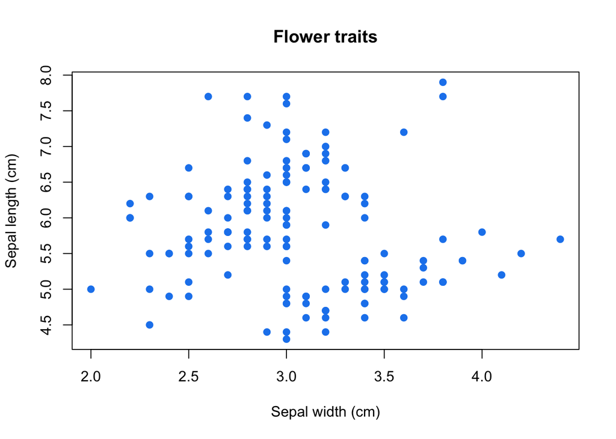

```r
# Basic customization
plot(Sepal.Length ~ Sepal.Width,
     main = "Flower traits",
     xlab = "Sepal width (cm)",
     ylab = "Sepal length (cm)",
     col = "dodgerblue2",
     pch = 19)
```

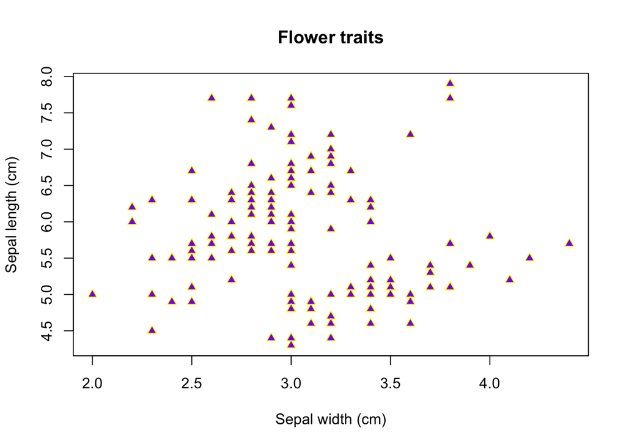

```r
# Changing shape and border color
plot(Sepal.Length ~ Sepal.Width,
     main = "Flower traits",
     xlab = "Sepal width (cm)",
     ylab = "Sepal length (cm)",
     col = "yellow",
     bg = "blueviolet",
     pch = 24)
```

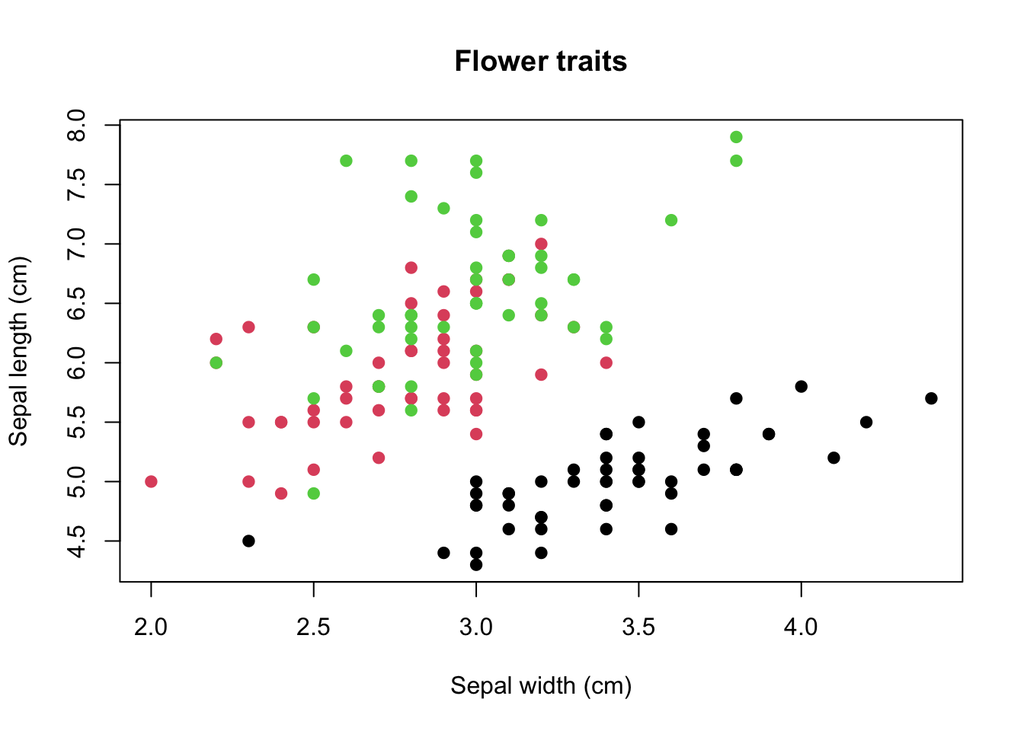

```r
# Coloring each species with a different color
plot(Sepal.Length ~ Sepal.Width,
     main = "Flower traits",
     xlab = "Sepal width (cm)",
     ylab = "Sepal length (cm)",
     col = iris$Species,
     pch = 19)
```

What if we want to plot only *Iris setosa*?

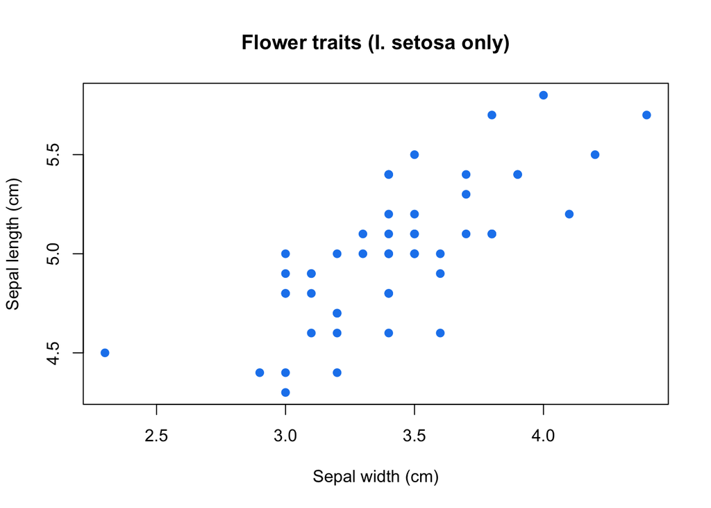

```r
# Subsetting data
dataS <- subset(iris, Species == "setosa")

# And making the plot:
plot(Sepal.Length ~ Sepal.Width,
     main = "Flower traits (I. setosa only)",
     xlab = "Sepal width (cm)",
     ylab = "Sepal length (cm)",
     col = "dodgerblue2",
     pch = 19,
     data = dataS)
```

### Boxplots: visually comparing variables

Let’s use boxplots to compare some variables:

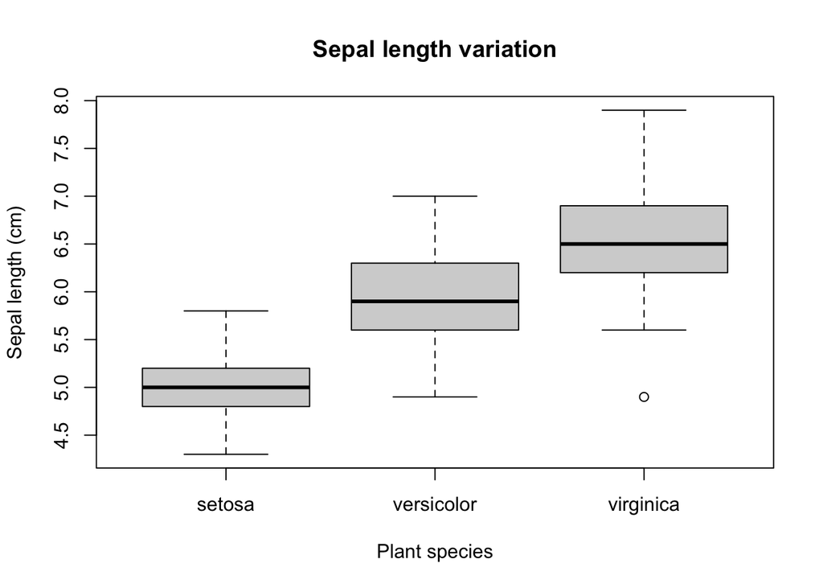

```r
boxplot(Sepal.Length ~ Species,
        main = "Sepal length variation",
        xlab = "Plant species",
        ylab = "Sepal length (cm)")
```

And what if we want to put four boxplots into a single figure? Easy to do! Let’s use the `par(mfrow = c(rows, cols))` command:

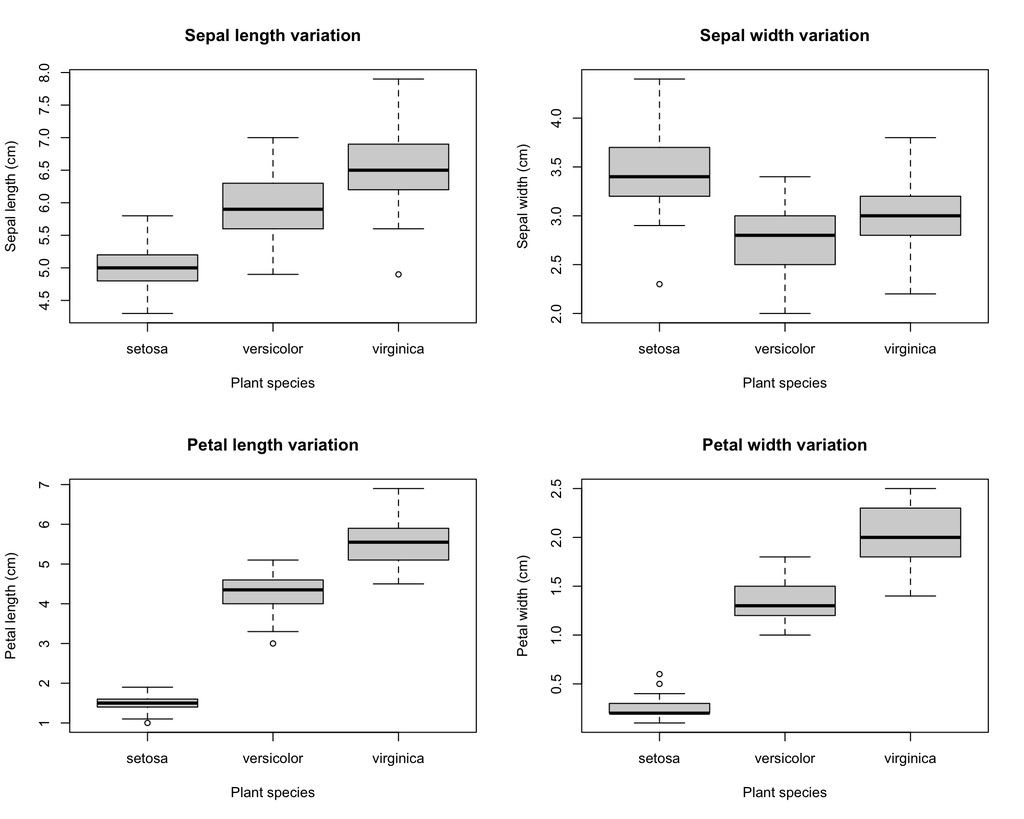

```r
par(mfrow = c(2, 2))
boxplot(Sepal.Length ~ Species, main = "Sepal length variation",
        xlab = "Plant species", ylab = "Sepal length (cm)")
boxplot(Sepal.Width ~ Species, main = "Sepal width variation",
        xlab = "Plant species", ylab = "Sepal width (cm)")
boxplot(Petal.Length ~ Species, main = "Petal length variation",
        xlab = "Plant species", ylab = "Petal length (cm)")
boxplot(Petal.Width ~ Species, main = "Petal width variation",
        xlab = "Plant species", ylab = "Petal width (cm)")
```

```r
par(mfrow = c(1, 1))
```

## Operating objects

We can make a series of mathematical and logical operations with our objects. Along with R sample datasets, we can also generate random data. With the code below, we will generate two variables `x` and `y` with a normal distribution and N = 500:

```r
x <- rnorm(500)
y <- rnorm(500)
```

And how do they look?

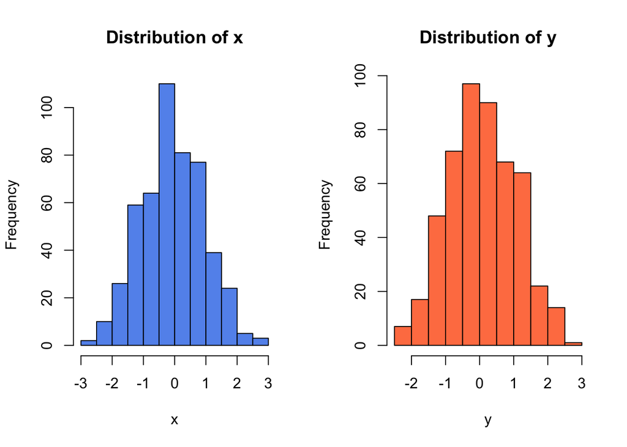

```r
par(mfrow = c(1, 2))
hist(x, col = "cornflowerblue", main = "Distribution of x")
hist(y, col = "coral", main = "Distribution of y")
```

```r
par(mfrow = c(1, 1))
```

How are `x` and `y` related?

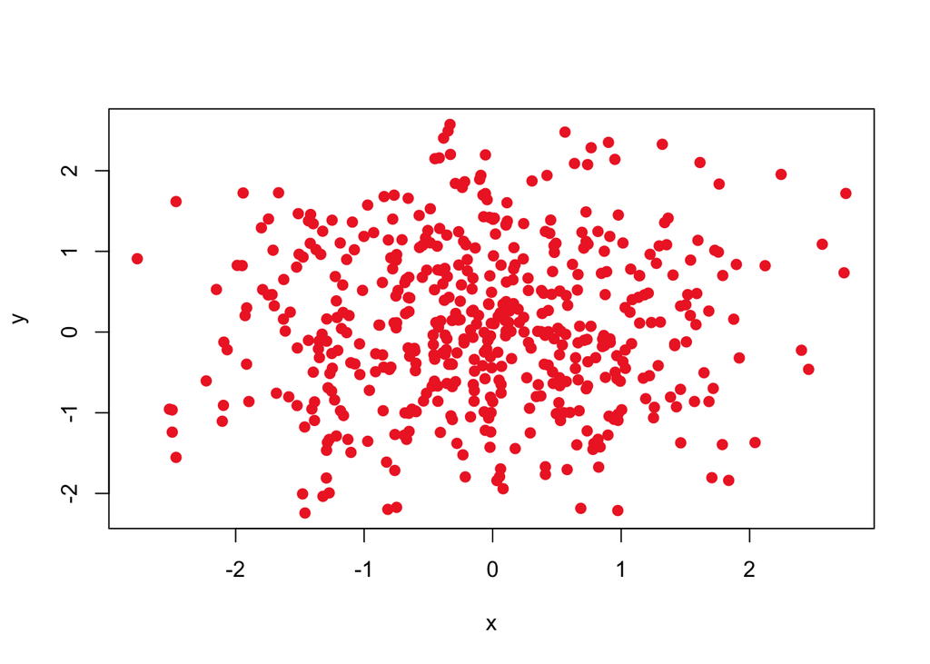

```r
plot(x, y, pch = 19, col = "firebrick2")
```

### Transforming variables

What if we want to use `y` in logarithmic scale? Let’s see how it affects the scatterplot:

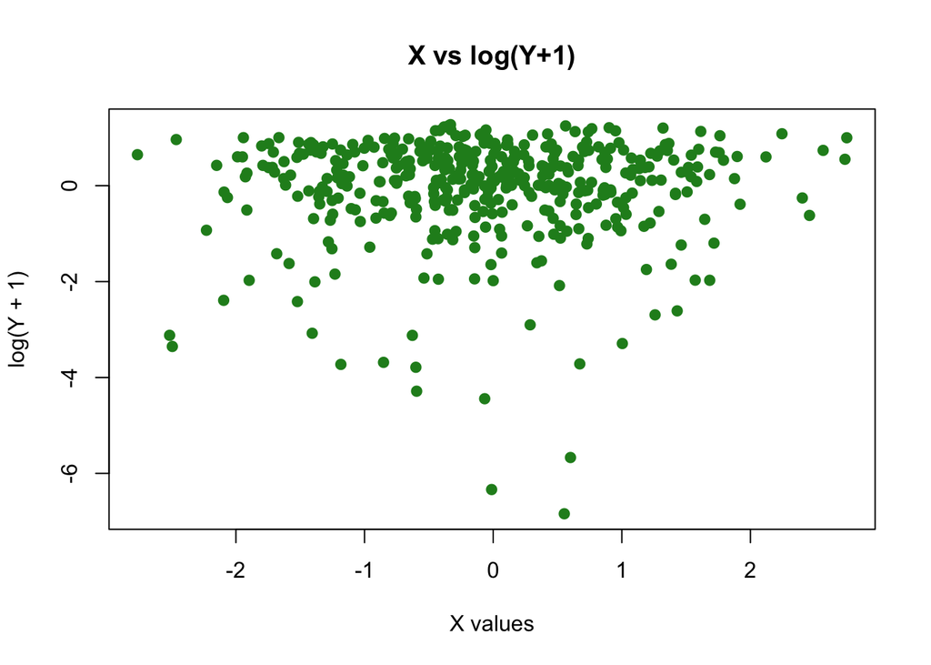

```r
# We can also perform mathematical operations with variables
ylog <- log(y + 1)
plot(x, ylog, pch = 19, col = "forestgreen",
     main = "X vs log(Y+1)",
     xlab = "X values",
     ylab = "log(Y + 1)")
```

And what if we want to multiply `x` by $\pi$?

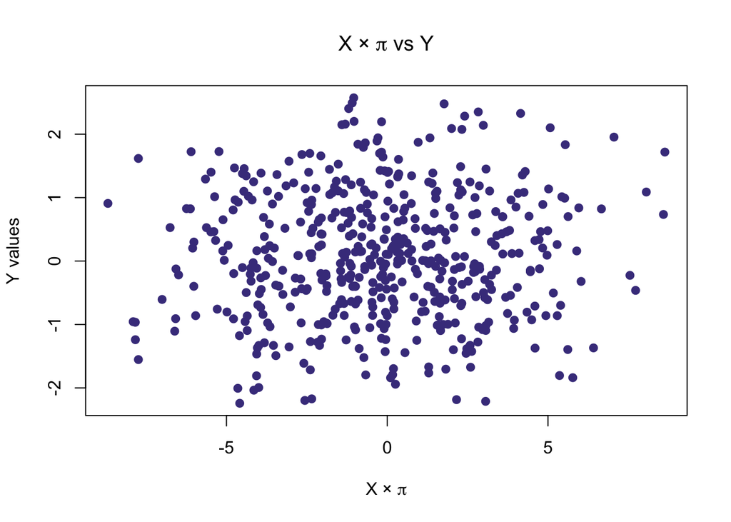

```r
xs <- x * pi
plot(xs, y, pch = 19, col = "darkslateblue",
     main = expression(paste("X × ", pi, " vs Y")),
     xlab = expression(paste("X × ", pi)),
     ylab = "Y values")
```

## Presenting results

The `cat()` function is useful for printing formatted results:

```r
cat("Summary of our tree study:\n")
```

```
## Summary of our tree study:
```

```r
cat("Mean height:", round(mean(tree_data$Height), 2), "meters\n")
```

```
## Mean height: 17.06 meters
```

```r
cat("Mean diameter:", round(mean(tree_data$Diameter), 2), "cm\n")
```

```
## Mean diameter: 43 cm
```

```r
cat("Total estimated biomass:", round(sum(tree_data$Biomass), 2), "kg\n")
```

```
## Total estimated biomass: 183.39 kg
```

## Quick reference: useful functions

Here’s a summary of basic functions covered in this lesson:

| Function | Description | Example |
| --- | --- | --- |
| `c()` | Combine values into a vector | `c(1, 2, 3)` |
| `mean()` | Calculate the mean | `mean(x)` |
| `sd()` | Calculate standard deviation | `sd(x)` |
| `sum()` | Calculate the sum | `sum(x)` |
| `min()` | Find minimum value | `min(x)` |
| `max()` | Find maximum value | `max(x)` |
| `length()` | Count elements | `length(x)` |
| `head()` | View first rows | `head(data)` |
| `tail()` | View last rows | `tail(data)` |
| `summary()` | Statistical summary | `summary(data)` |
| `levels()` | View factor levels | `levels(factor)` |
| `subset()` | Subset data | `subset(data, condition)` |
| `data.frame()` | Create a data frame | `data.frame(a = 1, b = 2)` |

## Final thoughts

R is a useful tool to work with any kind of data. As long as we understand how objects work and learn some basic coding skills, we can accomplish virtually any data analysis task. A useful guide of basic R commands is available [here](https://iqss.github.io/dss-workshops/R/Rintro/base-r-cheat-sheet.pdf) to download as a PDF file.

Licensing Creative Commons License

Licensed under a Creative Commons Attribution-ShareAlike 4.0 International License.  
2025 - Francisco E. Fontúrbel